# DATA2002 Report

Aaron Hua

## 0.1 USYD DATA student survey dataset

### 0.1.1 Introduction

This dataset is a collection of answers from a survey questionnaire given to students currently enrolled in DATA2002/DATA2902 at The University of Sydney. The data contains various unique questions that range from gender to the number of Covid test that person may have had. This dataset is a only a sample (211) from the entire population (696 students) of relevant students. This may effect the meaning of the results possibly creating error. However, it is a random sample of the DATA population, as the students are spread across multiple variables such as current country of residence, enrollment between DATA2002 and DATA2902, and current year of university.

When working with data it is important to consider its credibility and a common way to determine that is by considering what biases can be seen when analyzing it. These can be sources of fault in the data collection phase that may distort the results a particular direction and in turn will not represent the information in a true fashion. With this dataset there can be a few biases for example, selection bias. Selection bias occurs when the data is obtained from the population subjectively. This can relate the survey dataset as the analysis of certain questions will be performed from a sample of DATA students while the question may pertain to a much greater population outside of the DATA student sample. An additional bias that can be seen when examining the survey questions is recall bias. This is relevant to certain question that require the participant to recall a past occurrence or event. The error will stem from the possible inaccuracy or incompleteness of the recollection and as a result create bias in the dataset.

To improve the collection of the data the questions asked during the survey could be more specific in the answers. This could be done by creating a multiple choice system for the participant to answer with. This will limit the number of irregular responses and reduce the amount of time need to clean the raw data. With recollection questions that require a number, the survey could also offer multiple ranges that the participant could decide between. Although this will not completely remove the recall bias it will however reduce it as they will be able to determine the range in which their response lies instead of an exact number.

### 0.1.2 Analysis

#### 0.1.2.1 Package Import

Before performing any analysis we first need to import the required packages into R.

```r
library(tidyverse)
library(gt)
library(janitor)
library(remotes)
```

#### 0.1.2.2 Import Dataset

Next is to import the raw csv file into R.

```r
url = "https://docs.google.com/spreadsheets/d/1-DmA1UUM6QmZyucYiutuZX4Q0omtSCDwSOCNzHibkto/export?format=csv"
survey = readr::read_csv("DATA2x02_survey.csv")
# colnames(survey) %>%
#   tibble() %>%
#   gt::gt()
```

Before going further, it is best to simplify the naming of the dataset making it easier to manage in the future.

```r
questions = colnames(survey)
short_names = c("time","covid_tests","living_arrangements","height",
                "wednesday","in_aus","math_ability","r_ability",
                "data2002","year","webcam","vaccination","social_media",
                "gender","steak_preference","dominant_hand","stress",
                "lonely","emails","sign_off","salary","unit","major","exercise")
colnames(survey) = short_names
```

**Question 1.** Is there any evidence that people currently living in Australia are more likely to be vaccinated?

In the current state of the world and this pandemic, the question of how Australia compares with other nations. Contemplating and evaluating this question could offer valuable information to determine whether the country is either falling behind or leading the world in global resolution. It could also offer information that can assist in decision making such as if Australia holds the capacity to assist in foreign aid.

To evaluation this question the first step would be to look at the data for “vaccination” and “in_aus”. Because the survey question was offered in a multiple choice style it allows less cleaning to consider the frequencies. It also categories the data as both categorical data and a suitable question for chi-square test for homogeneity.

Vaccination

```r
survey %>% janitor::tabyl(vaccination)
```

```
##                      vaccination  n    percent valid_percent
##             I'm fully vaccinated 70 0.33175355    0.33816425
##         I'm partially vaccinated 59 0.27962085    0.28502415
##  I do not want to get vaccinated  7 0.03317536    0.03381643
##           Not yet, but I want to 71 0.33649289    0.34299517
##                             <NA>  4 0.01895735            NA
```

when viewing the data for vaccination it can be seen that the responses can be categorized into 4 main choices and a “NA” for those non-responses. There are possible limitations that can factor into how this question is answered. An example is separating those between vaccinated and non-vaccinated. Because it is safe to assume that if the participant has had 1 vaccination than it is highly likely that they will also be getting their second we can assume that fully vaccinated people and partially vaccinated people can be combine to create a “vaccinated” group. For those that have not been vaccinated at all in that point in time will also be combined to form the “Non-vaccinated” group. Although it is possible that some non-vaccinated will get the vaccine in the future we can assume that this point in time they do not have the vaccine. Next we look at the “in_aus” data below.

In Australia

```r
survey %>% janitor::tabyl(in_aus)
```

```
##  in_aus   n     percent valid_percent
##      No  70 0.331753555     0.3349282
##     Yes 139 0.658767773     0.6650718
##    <NA>   2 0.009478673            NA
```

The “in_aus” data is separated between the Boolean choices of Yes or No. Although it may seem simple there are considerations that must be considered, such as the difference between the people currently in Australia and those that are not. The difference is quite large meaning that the data can be skewed, misleading the result.

**Hypothesis**: $H_0$: p11 = p21 & p12 = p22 Vs $H_1$: p11 ≠ p21 & p12 ≠ p22 OR $H_0$: the outcomes of Vaccinated and non-vaccinated are homogeneous with both sample populations that are currently not in Australia and are in the Australia Vs $H_1$: the outcomes of the vaccinated and non-vaccinated are not homogeneous with both sample populations that are currently not in Australia and are in the Australia.

**Assumptions**: Observations are randomly sampled from the two independent populations and $e_{ij} = y_{i.}y_{.j}/n ≥ 5$.

```r
# variable table
variable1 <- c("p11", "p12", "p11 + p12 = 1")
variable2 <- c("p21", "p22", "p21 + p22 = 1")
variable3 <- c(variable1, variable2)
variable_table <- matrix(variable3, byrow = TRUE, nrow = 2)
colnames(variable_table) <- c("Vaccinated", "Non-Vaccinated", "Total")
rownames(variable_table) <- c("Not in Aus", "In Aus")
variable_table
```

```
##            Vaccinated Non-Vaccinated Total
## Not in Aus "p11"      "p12"          "p11 + p12 = 1"
## In Aus     "p21"      "p22"          "p21 + p22 = 1"
```

When creating a contingency table it can show the separation between each group in a 2 X 4 table.

```r
# data set
contingency <- table(survey$in_aus, survey$vaccination)
contingency
```

```
##
##       I'm fully vaccinated I'm partially vaccinated
##   No                    44                       13
##   Yes                   26                       45
##
##       I do not want to get vaccinated Not yet, but I want to
##   No                                0                     12
##   Yes                               7                     59
```

The next step is to create a contingency table that combines the 2 vaccinated groups and the 2 non-vaccinated groups into a 2 X 2 contingency table.

```r
not_in_aus_vector <- c(44+13, 0+12)
in_aus_vector <- c(26+45, 7+59)
table <- c(not_in_aus_vector, in_aus_vector)
tab <- matrix(table, byrow = TRUE, nrow = 2)

vac_names <- c("Vaccinated", "Non-Vaccinated")
aus_names <- c("Not in Aus", "In Aus")
colnames(tab) <- vac_names
rownames(tab) <- aus_names
tab
```

```
##            Vaccinated Non-Vaccinated
## Not in Aus         57             12
## In Aus             71             66
```

Obtain the total population using the *sum* function and the total for each row and each column using the *apply* function

```r
n = sum(contingency) # Total population

row_total = apply(tab, 1, sum) # row Total
row_total
```

```
## Not in Aus     In Aus
##         69        137
```

```r
col_total = apply(tab, 2, sum) # column total
col_total
```

```
##     Vaccinated Non-Vaccinated
##            128             78
```

Turn both the row sum and column sum into a matrix using the *matrix* function preparing it for the following steps to calculate the expected frequencies.

```r
rt = matrix(row_total, nrow = 2, ncol = 2, byrow = FALSE)
rt
```

```
##      [,1] [,2]
## [1,]   69   69
## [2,]  137  137
```

```r
ct = matrix(col_total, nrow = 2, ncol = 2, byrow = TRUE)
ct
```

```
##      [,1] [,2]
## [1,]  128   78
## [2,]  128   78
```

TO check the assumption stated above ($e_{ij} = y_{i.}y_{.j}/n ≥ 5$), we multiple the row total and the column total and divide the result by the total population calculated previously. Then check if the condition is TRUE.

```r
etab = (rt * ct)/n
etab
```

```
##          [,1]     [,2]
## [1,] 42.87379 26.12621
## [2,] 85.12621 51.87379
```

```r
etab >= 5
```

```
##      [,1] [,2]
## [1,] TRUE TRUE
## [2,] TRUE TRUE
```

Once the expected values are confirmed to be greater than or equal to 5 as assumed. The test statistic can be calculated by using the formula:
$$T = \sum_{i=1}^{2}\sum_{j=1}^{2}\frac{(Y_{ij} - e_{ij})^2}{e_{ij}}$$
Under $H_0$, T ~ $X^{2}_{1}$ approximately.

```r
t0 = sum((tab - etab)^2/etab) # test statistic
t0
```

```
## [1] 18.48328
```

**Observed Test Statistic**: $t_0$ = 18.48328

Then calculate the degrees of freedom by using $(r - 1)(c - 1)$ which in our circumstances is $(2 - 1)(2 - 1) = 1$. To calculate the P-value using the *pchisq* function include the calculate test statistic and the degrees of freedom.

```r
p.value = 1 - pchisq(t0, df = 1)
p.value
```

```
## [1] 1.714017e-05
```

**P-value**: $P(T ≥ t_0) =P(x^2_1 ≥ 18.48328) = 1.71e^{-5} = 0.0000171$  
**Decision**: Since the P-value is less than 0.05 than there is no evidence that there is a homogeneous relationship between the two sample populations of those currently in Australia and those not in Australia with the the Covid vaccine. Therefore we reject the null hypothesis meaning the data favors the alternative hypothesis.

**Question 2.** Is it more likely for women to live with their parents?

There have been many arguments for both sides of the question that say women are more likely to live with their parents and women are less likely to live with their parents. To determine the answer to this question statistically, a hypothesis test can be performed with the given dataset. However there are certain limitations that apply and should be carefully considered when analyzing. This can be seen when viewing the data of the relevant factors. The categorical data can be best answered by using a chi-square test of independence as the question is determining if the gender is dependent on their living arrangement. There will be a bias as the dataset is collected from DATA students in the 18 - 24 year old age group. Therefore not completely representing a truly random sample.

Gender

```r
survey %>% janitor::tabyl(gender)
```

```
##        gender  n     percent valid_percent
##             f  1 0.004739336   0.004854369
##             F  1 0.004739336   0.004854369
##        Famale  1 0.004739336   0.004854369
##         Femal  1 0.004739336   0.004854369
##        female 27 0.127962085   0.131067961
##        Female 42 0.199052133   0.203883495
##             M  4 0.018957346   0.019417476
##          male 33 0.156398104   0.160194175
##          Male 88 0.417061611   0.427184466
##          MALE  1 0.004739336   0.004854369
##           man  1 0.004739336   0.004854369
##           Man  2 0.009478673   0.009708738
##    Non-binary  1 0.004739336   0.004854369
##         Woman  2 0.009478673   0.009708738
##  Woman/Female  1 0.004739336   0.004854369
##          <NA>  5 0.023696682            NA
```

The responses for gender differed between spelling and capitalization. To clean the raw data, a “remotes” package and a “ropenscilabs/gendercoder” which will help organise the gender data.

```r
# remotes::install_github("ropenscilabs/gendercoder")

survey = survey %>%
  mutate(
    gender = case_when(
      gender == "Woman/Female" ~ "Female",
      TRUE ~ gender
    ),
    gender_clean = gendercoder::recode_gender(gender))

survey %>% janitor::tabyl(gender_clean)
```

```
##  gender_clean   n     percent valid_percent
##        female  75 0.355450237   0.365853659
##          male 129 0.611374408   0.629268293
##    non-binary   1 0.004739336   0.004878049
##          <NA>   6 0.028436019            NA
```

Next is to examine the living arrangement data. There were many responses to the living arrangement question in the survey. To reduce the number of options a *fct_lump_n* function is used to combine responses with less than or equal to 5 frequencies into an “other” category.  
Living arrangement

```r
# survey %>% janitor::tabyl(living_arrangements)

survey = survey %>% mutate(
  living_arrangements_clean = fct_lump_n(living_arrangements, n = 5)
)

survey %>% tabyl(living_arrangements_clean)
```

```
##        living_arrangements_clean   n    percent valid_percent
##                            Alone  14 0.06635071    0.06730769
##  College or student accomodation  18 0.08530806    0.08653846
##                      Share house  13 0.06161137    0.06250000
##                     With parents 147 0.69668246    0.70673077
##                     With partner  12 0.05687204    0.05769231
##                            Other   4 0.01895735    0.01923077
##                             <NA>   3 0.01421801            NA
```

The limitations of these datasets are the many options that each have. For the sake of simplicity and relevance non-binary genders and null responses will be stripped. To reduce the categories of living arrangements each will be separated into 2 main groups. Those that live with their parents and those that do not. First is to determine the frequencies of the two combined in a contingency table.

```r
data_table <- table(survey$gender_clean, survey$living_arrangements_clean)
data_table <- data_table[-3,] # remove non-binary
data_table
```

```
##
##          Alone College or student accomodation Share house With parents
##   female     2                               6           4           58
##   male      12                              12           9           85
##
##          With partner Other
##   female            2     1
##   male              8     3
```

**Hypothesis**: $H_0$: $p_{ij} = p_{i.}p_{.j}$, *i* = 1, 2; *j* = 1, 2 Vs $H_1$: Not all equalities hold OR $H_0$: The two categorical variables are independent in the population (i.e. living arrangment is independent of gender) Vs $H_1$: The two categorical variables are not independent in the population (i.e. living arrangement is dependent of gender).

**Assumptions**: It is assumed that the observations are independent and that the expected value is $e_{ij} = y_{i.}y_{.j}/n ≥ 5$.

First start by collecting the relevant data and forming a 2 X 2 contingency table.

```r
female_vector <- c(58, 2+6+4+2+1)
male_vector <- c(85, 12+12+9+8+3)
data_tab <- c(female_vector, male_vector)
gender_name <- c("Female", "Male")
living_name <- c("With parents", "Without parents")

data_matrix <- matrix(data_tab, nrow = 2, byrow = TRUE)
rownames(data_matrix) <- gender_name
colnames(data_matrix) <- living_name

data_matrix
```

```
##        With parents Without parents
## Female           58              15
## Male             85              44
```

Next, is to calculate the row total and column total from the contingency table and form them into a maxtrix for further calculation.

```r
n = sum(data_matrix) # total population
data_row_total = apply(data_matrix, 1, sum)
data_row_total
```

```
## Female   Male
##     73    129
```

```r
data_col_total = apply(data_matrix, 2, sum)
data_col_total
```

```
##    With parents Without parents
##             143              59
```

```r
data_row_mat = matrix(data_row_total, 2, 2, byrow = FALSE)
data_row_mat
```

```
##      [,1] [,2]
## [1,]   73   73
## [2,]  129  129
```

```r
data_col_mat = matrix(data_col_total, 2, 2, byrow = TRUE)
data_col_mat
```

```
##      [,1] [,2]
## [1,]  143   59
## [2,]  143   59
```

With the values calculated above, we can calculate the expected values with $e_{ij} = y_{i.}y_{.j}/n$ and check that the assumptions stated above are satisfied ($e_{ij} ≥ 5$).

```r
edata = data_row_mat * data_col_mat/n # expected value
edata
```

```
##          [,1]     [,2]
## [1,] 51.67822 21.32178
## [2,] 91.32178 37.67822
```

```r
edata >= 5 # check assumption
```

```
##      [,1] [,2]
## [1,] TRUE TRUE
## [2,] TRUE TRUE
```

Once the assumptions have been checked and satisfied the test statistic can be calculated with:
$$T = \sum_{i=1}^{2}\sum_{j=1}^{2}\frac{(Y_{ij} - e_{ij})^2}{e_{ij}}$$
Under $H_0$, T ~ $X^{2}_{1}$ approximately.

```r
t0 = sum((data_matrix - edata)^2/edata) # test statistic
t0
```

```
## [1] 4.146031
```

**Observed Test Statistic**: $t_0$ = 4.1460 Finally the P-value can be calculated using the *pchisq* function using the observed test statistic, degrees of freedom = $(r - 1)(c - 1)$ (similar to previous question), and stating the *lower.tail* as FALSE.

```r
p_value = pchisq(t0, 1, lower.tail = FALSE)
p_value
```

```
## [1] 0.04173223
```

**P-value**: $P(T ≥ t_0) = P(x_1^2 ≥ 4.1460) = 0.04173$  
**Decision**: Since the P-value is less that the significance level of 0.05, we reject the null hypothesis that gender is independent of living arrangement and accept the alternative hypothesis that the two variables are related.

**Question 3.** Is the average male height consistent with the average male height of Australia?

According to a statistic from MedicineNet the average height for men is **179 cm** (Average Height for Men Worldwide, 2019). The objective is to determine whether or not the average from the sample data collected corresponds with that statistic.To test this statistic against the given dataset an appropriate hypothesis test should be performed to test the mean of the two datasets. A limitation that can occur while analyzing is that with the sample population is a very small collection of the entire population of Australia. This can greatly effect the result. The small sample of male height in this dataset compared to an external figure should be calculated using a one-sample t-test. The first step to analyzing this question is by viewing and cleaning the data.

Height

```r
tail(survey %>% janitor::tabyl(height))
```

```
##                                         height n     percent valid_percent
##                                          6'3'' 1 0.004739336   0.004830918
##                                           6'3" 2 0.009478673   0.009661836
##                                            6’2 2 0.009478673   0.009661836
##                                       not very 1 0.004739336   0.004830918
##  Short enough to take offense at this question 1 0.004739336   0.004830918
##                                           <NA> 4 0.018957346            NA
```

As seen the responses to the question in the survey is fairly spread in format and measuring system. To clean this data and make it uniform the *parse_number* function is used to grab only numbers from the responses and the *mutate* function is used with a *case_when* function to change participants that have used meters and transforming them into cm and those that have used the imperial system and transform them into null variables.

```r
survey = survey %>%
  dplyr::mutate(
    height_clean = readr::parse_number(height),
    height_clean = case_when(
      height_clean <= 2.5 ~ height_clean * 100,
      height_clean <= 9 ~ NA_real_,
      TRUE ~ height_clean
    )
  )
```

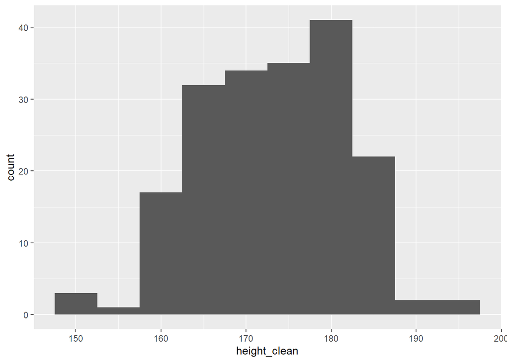

```r
survey %>%
  ggplot() +
  aes(x = height_clean) +
  geom_histogram(binwidth = 5)
```

```r
data_height = (survey["height_clean"] %>% filter(survey["gender"]=="male"))
X_data <- na.omit(data_height)
X_data
```

```
## # A tibble: 31 x 1
##    height_clean
##           <dbl>
##  1          176
##  2          180
##  3          172
##  4          167
##  5          180
##  6          171
##  7          176
##  8          173
##  9          178
## 10          186
## # ... with 21 more rows
```

**Assumptions**: $X_i$ are *iid rv* and follow $N(\mu, \sigma^2)$.

The mean is calculated using a *mean* function.

```r
X <- c(176, 180, 172, 167, 180, 171, 176, 173, 178, 186, 180, 179, 176, 184, 176, 180, 195, 178, 176, 175, 169, 173, 183, 183, 176, 180, 170, 178, 171, 173, 176)
mean(X)
```

```
## [1] 177.0968
```

The standard deviation is found using the *sd* function.

```r
sd(X)
```

```
## [1] 5.617561
```

The t-test can be calculated by using the *t.test* function. However, as using R may not always be accurate a manual calculation can be done too.

```r
t.test(X, mu = 179, alternative = "less")
```

```
##
##  One Sample t-test
##
## data:  X
## t = -1.8864, df = 30, p-value = 0.03448
## alternative hypothesis: true mean is less than 179
## 95 percent confidence interval:
##      -Inf 178.8092
## sample estimates:
## mean of x
##  177.0968
```

To calculate it manually, using test statistic formula:
$$T = \frac{x̄ - \mu_0}{\frac{S}{\sqrt{n}}}$$
Under $H_0$, T ~ $t_{n - 1}$

```r
n = length(X)
t0 = (mean(X) - 179)/(sd(X)/sqrt(n))
t0
```

```
## [1] -1.886355
```

**Observed Test Statistic**: $t_0$ = -1.8864  
The P-value can be calculated using *pt* function.

```r
pval = pt(t0, n - 1)
pval
```

```
## [1] 0.03448028
```

**Covid tests (poisson distribution)**

**Hypothesis**: $H_0$: number of Covid tests follows a Poisson distribution Vs $H_1$: number of Covid tests do not follow a Poisson Distribution.

**Assumptions**: Expected frequencies, $e_i = np_i ≥ 5$ and the observations are independent.

Observe the data for Covid tests from the dataset.

```r
survey %>% janitor::tabyl("covid_tests")
```

```
##  covid_tests   n     percent valid_percent
##            0 126 0.597156398   0.605769231
##            1  40 0.189573460   0.192307692
##            2  16 0.075829384   0.076923077
##            3   4 0.018957346   0.019230769
##            4   5 0.023696682   0.024038462
##            5   9 0.042654028   0.043269231
##            6   1 0.004739336   0.004807692
##            7   1 0.004739336   0.004807692
##            8   4 0.018957346   0.019230769
##           10   2 0.009478673   0.009615385
##           NA   3 0.014218009            NA
```

Because a Poisson distribution an average rate time is required $\lambda$. To find an estimate of $\lambda$ use the formula:
$$\lambda = \frac{\sum(i \times y_i)}{\sum y_i}$$

```r
y = c(126, 40, 16, 4, 5, 9, 1, 1, 4, 0, 2) # Frequency
x = c(0:10) # Number of tests
n = sum(y)
k = length(y)

lam = sum(y * x)/n
lam
```

```
## [1] 1.028846
```

A *dpois* function to find the probability the number of tests successes in a period of $\lambda$.

```r
p = dpois(x, lam) # p_i
p
```

```
##  [1] 3.574191e-01 3.677293e-01 1.891684e-01 6.487507e-02 1.668662e-02
##  [6] 3.433592e-03 5.887731e-04 8.653670e-05 1.112912e-05 1.272239e-06
## [11] 1.308938e-07
```

Then the last index is changed to suit the probability sum of 1.

```r
p[11] = 1 - sum(p[1:10])
round(p, 5)
```

```
##  [1] 0.35742 0.36773 0.18917 0.06488 0.01669 0.00343 0.00059 0.00009 0.00001
## [10] 0.00000 0.00000
```

The expected frequencies are then calculated and checked by following the formula:
$$e_i = np_i$$

```r
ey = n * p # expected frequencies
ey
```

```
##  [1] 7.434318e+01 7.648769e+01 3.934703e+01 1.349402e+01 3.470816e+00
##  [6] 7.141872e-01 1.224648e-01 1.799963e-02 2.314857e-03 2.646257e-04
## [11] 3.000936e-05
```

```r
ey >= 5 # check assumption
```

```
##  [1]  TRUE  TRUE  TRUE  TRUE FALSE FALSE FALSE FALSE FALSE FALSE FALSE
```

Because the higher number of Covid tests are less than 5 to resolve that, the FALSE subjects will be combined into the nearest TRUE subject for both the frequencies and the expected frequencies.

```r
yr = c(y[1:3], sum(y[4:11])) # adjust to fit assumption
yr
```

```
## [1] 126  40  16  26
```

```r
eyr = c(ey[1:3], sum(ey[4:11]))
eyr
```

```
## [1] 74.34318 76.48769 39.34703 17.82209
```

The test statistic is calculated using the formula:
$$T = \sum_{i=1}^k \frac{(Y_i - np_i)^2}{np_i}$$

```r
cr = length(yr)
t0 = sum((yr -eyr)^2/eyr) # test statistic
t0
```

```
## [1] 70.90525
```

**Observed Test Statistic**: $t_0$ = 70.9053

```r
p.val = 1 - pchisq(t0, df = cr - 1 -1)
p.val
```

```
## [1] 4.440892e-16
```

**P-value**: $P(T ≥ t_0) = P(X_2^2 ≥ 70.9053)$ < 0.00001  
**Decision**: Since the P-value is very small and is less than 0.05, we reject the null hypothesis therefore the data is not consistent with a Poisson distribution.

### 0.1.3 Reference:

Average Height for Men Worldwide (Stats Inside). (2019, November 18). MedicineNet. https://www.medicinenet.com/height_men/article.htm